# Spaitial Data Science Ch1. Getting Started

## 1.1 A first map

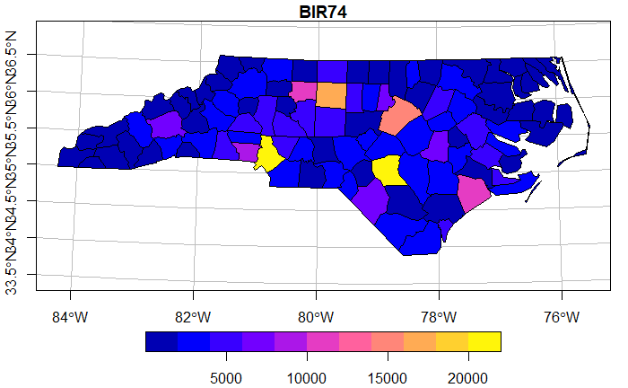

```r
library(tidyverse)
library(sf)

system.file("gpkg/nc.gpkg", package="sf") %>%
  read_sf() %>%
  st_transform(32119) %>%
  select(BIR74) %>%
  plot(graticule = TRUE, axes = TRUE)
```

여기서 `tidyverse`는 tidyverse 함수와 방법에 필요하고, `sf`는 공간적 명령어와 공간적 tidyverse 방법에 필요함. 패키지 `sf`는 단순한 피쳐를 실행하는데 있어, 벡터 데이터를 엔코드하는 표준화된 방식임. 패키지 `sf`에서 대부분의 명령어는 `st_`로 시작하는데, 이는 spatialtemporal을 줄인 말로, PostGIS에서도 사용되는 규약임.

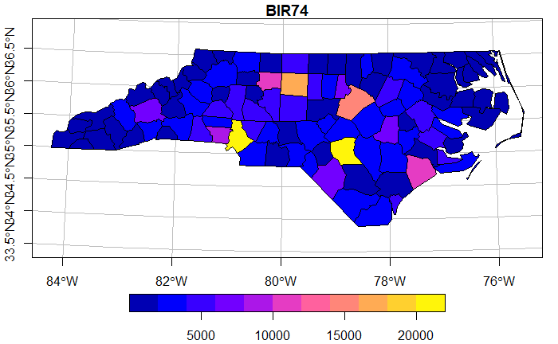

```r
library(tidyverse)
library(sf)
system.file("gpkg/nc.gpkg", package="sf") %>%
  read_sf() %>%
  st_transform(32119) %>%                      # st_transform 은 새로운 참조체계(EPSG코드 32119의 노스캐롤라이나 주)로 변환됨
  select(BIR74) %>%
  plot(graticule = TRUE, axes = TRUE)
```

```r
ggplot() + geom_sf(data = nc.32119) + aes(fill = BIR74) +
  theme(panel.grid.major = element_line(color = "white")) +
  scale_fill_gradientn(colors = sf.colors(20))
```

[output not shown]

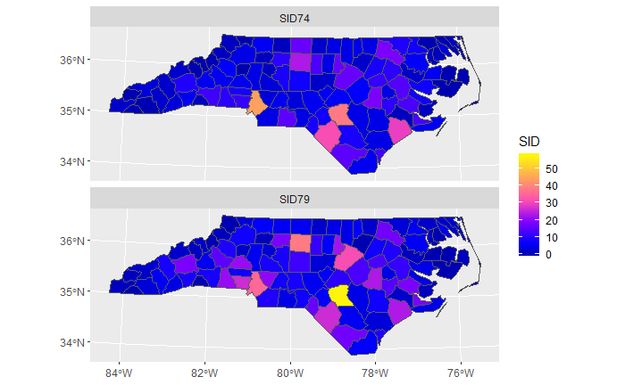

```r
nc.32119 %>% select(SID74, SID79) %>% gather(VAR, SID, -geom) -> nc2
ggplot() + geom_sf(data = nc2, aes(fill = SID)) + facet_wrap(~VAR, ncol = 1) +
  scale_y_continuous(breaks = 34:36) +
  scale_fill_gradientn(colors = sf.colors(20)) +
  theme(panel.grid.major = element_line(color = "white"))
```

## 1.2 Reading and writing

```r
st_drivers("raster") %>% nrow()
```

```
[1] 136
```

(GDAL의 같은 버전을 사용 중일때는, `sf`에서 이용가능한 드라이버는 rgdal과 같음)

### 1.2.1 GDAL

`st_drivers` 는 GDAL에서 이용가능한 드라이버를 리스트로 보여주는데, 이러한 라이브러리는 R에서 뿐만 아니라 파이썬, QGIS, PostGis 등에서 사용중에 있음. 다른 R 패키지 및 시스템 라이브러리에 대한 `sf`의 의존성은 아래 그림과 같음

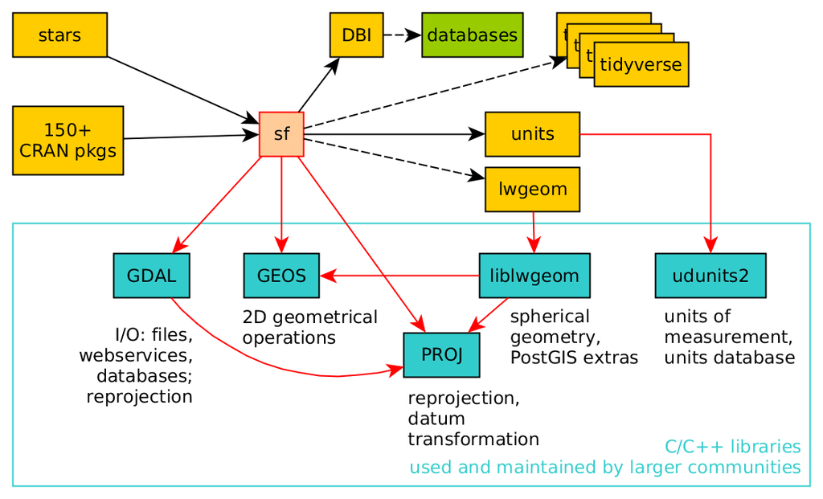

sf_dependence

### 1.2.2 `st_read` or `read_sf` ?

`st_read`는 벡터데이터를 읽는 함수. `read_sf`함수는 크게 보면 `st_read`와 동일하지만, 몇가지 tidyverse 스타일 디폴트를 선택함: - `st_read`는 짧은 리포트 - `read_sf`는 공간 data frame 대신 공간 tibble - `read_sf`는 입력값으로 리스트 컬럼(list-columns)을 인정

### 1.2.3 reading and writing raster data

래스터 데이터는 `stars` 패키지로부터 함수 `read_stars`를 이용하여 읽어들일 수 있음

```r
library(stars)
tif = system.file("tif/L7_ETMs.tif", package = "stars")
(x = tif %>% read_stars())
```

```
stars object with 3 dimensions and 1 attribute
attribute(s):
  L7_ETMs.tif
 Min.   :  1.00
 1st Qu.: 54.00
 Median : 69.00
 Mean   : 68.91
 3rd Qu.: 86.00
 Max.   :255.00
dimension(s):
```

[output not shown]

[figure not shown]

유사하게, 우리는 `write_stars`로 `stars` 객체로 된 래스터 데이터를 쓰기(write)할 수 있음

```r
tif_file = paste0(tempfile(), ".tif")
write_stars(x, tif_file)
```

우리는 꺼꾸로 래스터 메타데이터를 읽을 수 있음(차원과 참조체계, 그러나 실제 픽셀값은 아님)

```r
read_stars(tif_file, proxy = TRUE)
```

```
stars_proxy object with 1 attribute in file:
$file59ac69b51ce7.tif
[1] "C:\\Users\\Public\\Documents\\ESTsoft\\CreatorTemp\\Rtmp6pSIfJ\\file59ac69b51ce7.tif"

dimension(s):
```

[output not shown]

### 1.2.4 Reading from files, and legacy shapefiles

어떤 경우엔, 공간데이터셋은 다중 파일들을 포함한다. 예를 들어 쉐이프 파일의 경우, “쉐이프파일”은 실제 공통의 접두사를 가진 팡링 셋으로 이해되어야 함 패키지 `sf`는 몇가지 쉐이프 파일을 가지고 있으며, `shape` 디렉토리에 있음

```r
list.files(system.file("shape/", package = "sf"))
```

```
 [1] "nc.dbf"                  "nc.prj"                  "nc.shp"                  "nc.shx"                  "olinda1.dbf"
 [6] "olinda1.prj"             "olinda1.shp"             "olinda1.shx"             "storms_xyz.dbf"          "storms_xyz.shp"
[11] "storms_xyz.shx"          "storms_xyz_feature.dbf"  "storms_xyz_feature.shp"  "storms_xyz_feature.shx"  "storms_xyzm.dbf"
[16] "storms_xyzm.shp"         "storms_xyzm.shx"         "storms_xyzm_feature.dbf" "storms_xyzm_feature.shp" "storms_xyzm_feature.shx"
```

```r
system.file("shape/nc.shp", package="sf") %>% st_read() -> nc
# system.file("shape", package="sf") %>% read_sf() -> something
```

```r
system.file("shape", package="sf") %>% st_layers()
```

```
Driver: ESRI Shapefile
Available layers:
```

| layer_name | geometry_type | features | fields |
| --- | --- | --- | --- |
| nc | Polygon | 100 | 14 |
| olinda1 | Polygon | 470 | 6 |
| storms_xyz | 3D Line String | 71 | 0 |
| storms_xyzm | Measured Line String | 71 | 0 |
| storms_xyzm_feature | Measured Line String | 71 | 1 |
| storms_xyz_feature | 3D Line String | 71 | 1 |

### 1.2.5 문자열 읽기

GeoJSON 데이터셋에 긴 문자벡터를 포함한 경우엔, `read_sf`로 전달되고 메모리로부터 읽어들임

```r
str <- '{
  "type": "FeatureCollection",
  "features": [
    { "type": "Feature",
      "geometry": {
        "type": "Point",
        "coordinates": [102.0, 0.5]
      },
      "properties": {
        "prop0": "value0"
      }
    },
    { "type": "Feature",
      "geometry": {
        "type": "LineString",
        "coordinates": [
          [102.0, 0.0], [103.0, 1.0], [104.0, 0.0], [105.0, 1.0]
        ]
      },
      "properties": {
        "prop0": "value0",
        "prop1": 0.0
      }
    },
    { "type": "Feature",
      "geometry": {
        "type": "Polygon",
        "coordinates": [
          [
            [100.0, 0.0], [101.0, 0.0], [101.0, 1.0],
            [100.0, 1.0], [100.0, 0.0]
          ]
        ]
      },
      "properties": {
        "prop0": "value0",
        "prop1": { "this": "that" }
      }
    }
  ]
}'
(sf_obj <- read_sf(str))
```

```
Simple feature collection with 3 features and 2 fields
geometry type:  GEOMETRY
dimension:      XY
bbox:           xmin: 100 ymin: 0 xmax: 105 ymax: 1
epsg (SRID):    4326
proj4string:    +proj=longlat +datum=WGS84 +no_defs
```

| prop0 | prop1 | geometry |
| --- | --- | --- |
| value0 | NA |  |
| value0 | 0.0 |  |
| value0 | { "this": "that" } |  |

### 1.2.6 데이터베이스

데이터가 두개의 경로를 거처 직접 공간 데이터베이스로부터 읽혀질 수 있음. 첫째는 SQLITE 데이터베이스와 같은 R의 표준 데이터베이스 인터페이스를 사용함.

```r
library(RSQLite)
db = system.file("sqlite/meuse.sqlite", package = "sf")
dbcon <- dbConnect(dbDriver("SQLite"), db)
(s = st_read(dbcon, "meuse.sqlite"))[1:3,]
```

```
Simple feature collection with 3 features and 13 fields
geometry type:  POINT
dimension:      XY
bbox:           xmin: 181025 ymin: 333537 xmax: 181165 ymax: 333611
epsg (SRID):    NA
proj4string:    NA
  ogc_fid cadmium copper lead zinc  elev       dist   om ffreq soil lime landuse dist.m              GEOMETRY
1       1    11.7     85  299 1022 7.909 0.00135803 13.6     1    1    1      Ah     50 POINT (181072 333611)
2       2     8.6     81  277 1141 6.983 0.01222430 14.0     1    1    1      Ah     30 POINT (181025 333558)
3       3     6.5     68  199  640 7.800 0.10302900 13.0     1    1    1      Ah    150 POINT (181165 333537)
```

다른 방법으론 GDAL 데이터베이스 드라이버를 사용하는 것, 예를 들어

```r
st_read(db)[1:3, ]
```

```
  cadmium copper lead zinc  elev       dist   om ffreq soil lime landuse dist.m              GEOMETRY
1    11.7     85  299 1022 7.909 0.00135803 13.6     1    1    1      Ah     50 POINT (181072 333611)
2     8.6     81  277 1141 6.983 0.01222430 14.0     1    1    1      Ah     30 POINT (181025 333558)
3     6.5     68  199  640 7.800 0.10302900 13.0     1    1    1      Ah    150 POINT (181165 333537)
```

전자의 접근법이 가진 잇점은 쿼리가 전달될 수 있다는 점임.

## 1.3 연습

1. `shape` 디렉토리로부터 `storms_xyz_feature` 쉐이프파일을 읽어라

```r
list.files(system.file("shape", package = "sf"))
```

```
 [1] "nc.dbf"                  "nc.prj"                  "nc.shp"                  "nc.shx"                  "olinda1.dbf"
 [6] "olinda1.prj"             "olinda1.shp"             "olinda1.shx"             "storms_xyz.dbf"          "storms_xyz.shp"
[11] "storms_xyz.shx"          "storms_xyz_feature.dbf"  "storms_xyz_feature.shp"  "storms_xyz_feature.shx"  "storms_xyzm.dbf"
[16] "storms_xyzm.shp"         "storms_xyzm.shx"         "storms_xyzm_feature.dbf" "storms_xyzm_feature.shp" "storms_xyzm_feature.shx"
```

```r
system.file("shape/storms_xyz_feature.shp", package="sf") %>% read_sf() -> storms
storms
```

```
Simple feature collection with 71 features and 1 field
geometry type:  LINESTRING
dimension:      XYZ
bbox:           xmin: -102.2 ymin: 8.3 xmax: 0 ymax: 59.5
z_range:        zmin: 924 zmax: 1017
epsg (SRID):    NA
proj4string:    NA
```

| Track | geometry |
| --- | --- |
| TONY |  |
| SANDY |  |
| RAFAEL |  |
| PATTY |  |
| OSCAR |  |
| NADINE |  |
| MICHAEL |  |
| LESLIE |  |
| KIRK |  |
| JOYCE |  |

[output cut: 61 more lines]

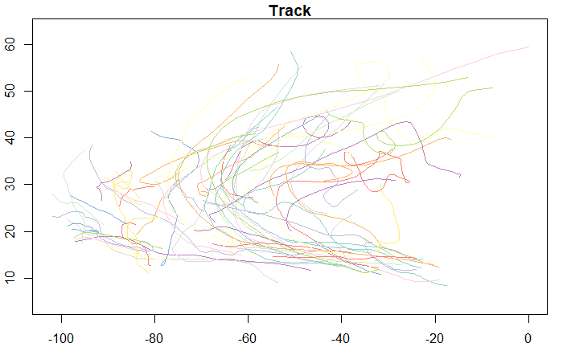

```r
plot(storms, axes = TRUE)
```

2. 이 파일을 사용자 컴퓨터의 디렉토리에 복사하고 거기에서 읽어라.

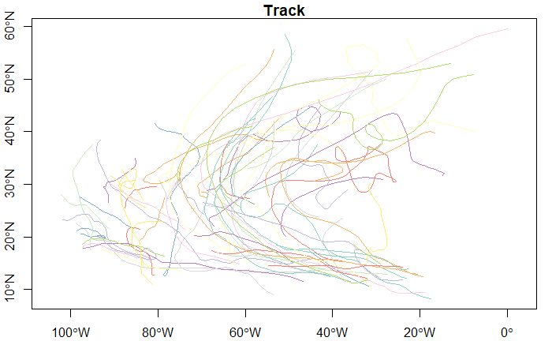

```r
storms <- st_read(system.file("shape/storms_xyz_feature.shp", package="sf"))
newsf <- st_zm(storms, drop=T, what='ZM')
newsf <- newsf %>%  st_set_crs(4326)
#st_write(newsf, "storms_xyz_feature1.shp")
plot(newsf, axes= TRUE)
```

```r
list.files(system.file("shape", package = "sf"))
```

```
 [1] "nc.dbf"                  "nc.prj"                  "nc.shp"                  "nc.shx"                  "olinda1.dbf"
 [6] "olinda1.prj"             "olinda1.shp"             "olinda1.shx"             "storms_xyz.dbf"          "storms_xyz.shp"
[11] "storms_xyz.shx"          "storms_xyz_feature.dbf"  "storms_xyz_feature.shp"  "storms_xyz_feature.shx"  "storms_xyzm.dbf"
[16] "storms_xyzm.shp"         "storms_xyzm.shx"         "storms_xyzm_feature.dbf" "storms_xyzm_feature.shp" "storms_xyzm_feature.shx"
```

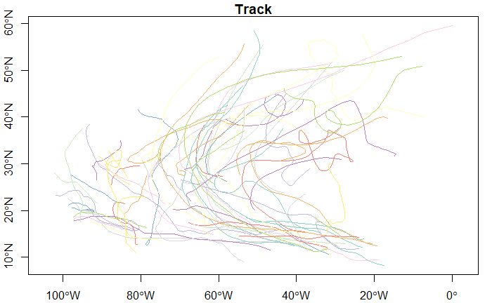

```r
system.file("shape/storms_xyz_feature.shp", package="sf") %>% read_sf() -> storms
storms1 <- storms %>% st_set_crs(4326)
plot(storms1, axes = TRUE)
```